# Statistical Learning Setup and Cross-Validation

Statistical Computing for Data Analysis

# From fitting to prediction

So far, we have focused on **fitting** a regression model.

We have mostly utilized the `lm()` function to fit a linear regression model. We use this model to do inference or understand the relationship between a response $Y$ and a set of covariates (collectively denoted as $X$).

But in many problems, especially for modern applications, the real goal is **prediction**:

- fit a model on data we already have
- use that model to predict outcomes for **new observations**
- evaluate the quality of those predictions.

In a statistical computing class, this raises a practical question: how do we assess a model’s ability to predict new observations?

# A simple regression example

We will use the `Auto` data and predict `mpg` from `horsepower`.

So our starting model is

$$\texttt{mpg} \sim \texttt{horsepower}.$$

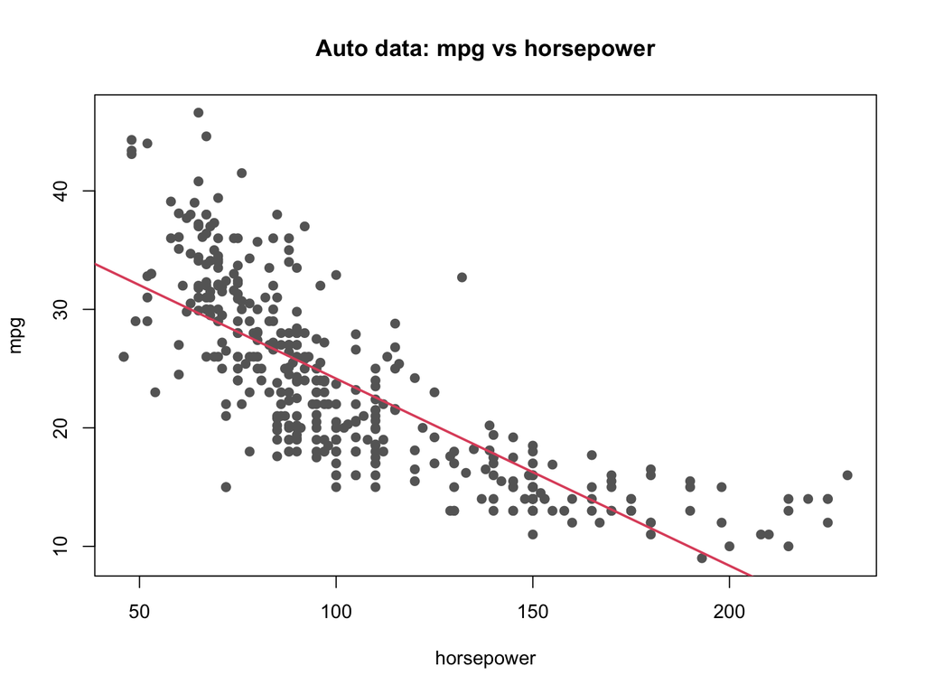

```r
library(ISLR2)

dat <- na.omit(Auto[, c("mpg", "horsepower")])
n <- nrow(dat)

plot(dat$horsepower, dat$mpg,
     pch = 19,
     col = "gray40",
     xlab = "horsepower",
     ylab = "mpg",
     main = "Auto data: mpg vs horsepower")

fit_full <- lm(mpg ~ horsepower, data = dat)
abline(fit_full, lwd = 2, col = 2)
```

# Prediction error and MSE

Suppose we fit a model and get predicted values $\widehat y_i$.

A common way to measure prediction error is the **mean squared error**:

$$\text{MSE} = \frac{1}{m}\sum_{i=1}^m (y_i - \widehat y_i)^2.$$

### Interpretation

- large errors are penalized more heavily because of the square
- smaller MSE means predictions are, on average, closer to the observed outcomes
- for regression, MSE is one of the most common prediction metrics

# Training MSE

The **training data** are the observations used to fit the model.

If we compute MSE on those same observations, we get the **training MSE**.

$$\text{Training MSE} =
\frac{1}{n_{\text{train}}}
\sum_{i \in \text{train}} (y_i - \widehat y_i)^2.$$

### Important point

Training MSE is usually **too optimistic** as a measure of future prediction performance, because the model has already seen those data, therefore by construction it is designed to fit that data well.

# Compute the training MSE

```r
fit_train_only <- lm(mpg ~ horsepower, data = dat)
pred_train <- predict(fit_train_only, newdata = dat)

train_mse <- mean((dat$mpg - pred_train)^2)
train_mse
```

```
## [1] 23.94366
```

# Why is this not enough?

A low training MSE does **not** guarantee good performance on new data.

Why not?

- the coefficients were chosen using these same observations
- the model is being evaluated on data it was fit to
- future observations will not be identical to the training sample

For prediction, the quantity we really care about is closer to:

### Real target

How well does the fitted model predict **new, unseen data**?

# Training set and test set

A basic solution is the **train/test split**.

We divide the data into two parts:

- **training set**: used to fit the model
- **test set**: held out and used only for evaluation

Then the **test MSE** is

$$\text{Test MSE} =
\frac{1}{n_{\text{test}}}
\sum_{i \in \text{test}} (y_i - \widehat y_i)^2,$$

where the predictions come from the model fit on the training set.

# One random train/test split

```r
set.seed(1)

test_id <- sample(1:n, size = round(n/2), replace = FALSE)
train_dat <- dat[-test_id, ]
test_dat  <- dat[test_id, ]

fit_split <- lm(mpg ~ horsepower, data = train_dat)

pred_train <- predict(fit_split, newdata = train_dat)
pred_test  <- predict(fit_split, newdata = test_dat)

train_mse <- mean((train_dat$mpg - pred_train)^2)
test_mse  <- mean((test_dat$mpg - pred_test)^2)

c(train_mse = train_mse, test_mse = test_mse)
```

```
## train_mse  test_mse
##  22.40046  25.90786
```

# How should we interpret this?

Typically:

- the **training MSE** is smaller
- the **test MSE** is larger

That is not by coincidence.

Tell me why.

### Takeaway

For prediction, **test error** is usually much more informative than training error.

# A weakness of one split

The validation-set approach is simple, but it has a weakness:

### The answer depends on the split.

If a different group of observations lands in the test set, we can get a different test MSE.

So one split can be:

- noisy
- unstable
- sensitive to random partitioning

# Repeated random splits

We can see this instability by repeating the train/test split many times.

```r
set.seed(2)

B <- 100
split_mse <- numeric(B)

for (b in 1:B) {
  test_id <- sample(1:n, size = round(0.25 * n), replace = FALSE)
  train_dat <- dat[-test_id, ]
  test_dat  <- dat[test_id, ]

  fit_b <- lm(mpg ~ horsepower, data = train_dat)
  pred_b <- predict(fit_b, newdata = test_dat)

  split_mse[b] <- mean((test_dat$mpg - pred_b)^2)
}

head(split_mse)
```

```
## [1] 26.04056 20.04188 21.20998 28.66126 25.09533 22.90998
```

```r
mean(split_mse)
```

```
## [1] 24.00697
```

```r
sd(split_mse)
```

```
## [1] 3.283192
```

# Visualizing the split-to-split variability

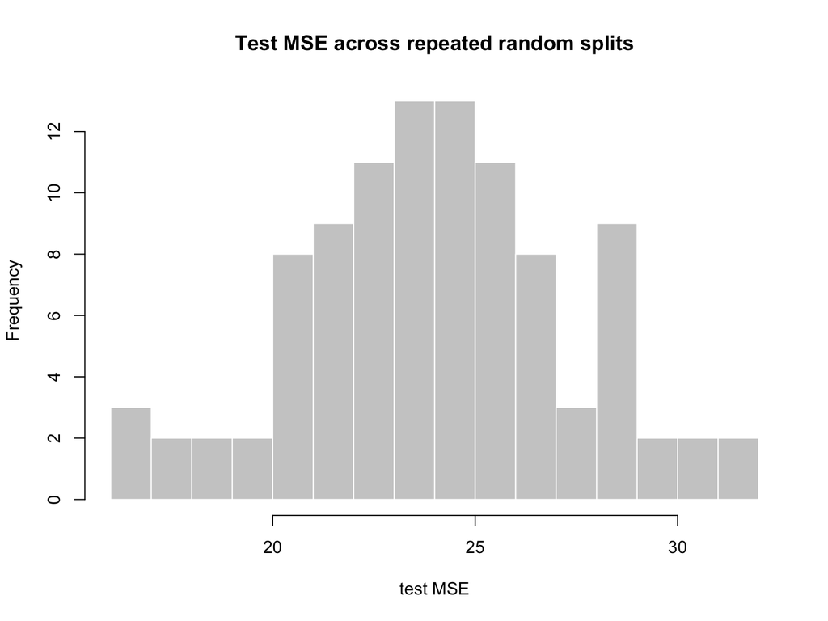

```r
hist(split_mse,
     breaks = 15,
     main = "Test MSE across repeated random splits",
     xlab = "test MSE",
     col = "gray80",
     border = "white")
```

### Interpretation

The single train/test split gives **one estimate** of prediction error. Repeated splits show that this estimate can vary quite a bit.

# Cross-validation

Cross-validation is a more systematic way to estimate prediction error.

The idea is to:

- split the data into several parts called **folds**
- hold out one fold at a time
- fit the model on the remaining folds
- evaluate prediction error on the held-out fold
- average the fold-specific errors

This uses the data more efficiently than a single train/test split.

# K-fold cross-validation

In **K-fold CV**:

1. divide the observations into $K$ folds
2. for fold $k$, fit the model on all observations not in fold $k$
3. predict the observations in fold $k$
4. compute the validation error for fold $k$
5. average the $K$ fold errors

$$\text{CV}_K = \frac{1}{K}\sum_{k=1}^K \text{Err}^{(k)}.$$

Common choices are $K=5$ or $K=10$.

# Create fold labels in base R

```r
set.seed(3)

K <- 5
fold_id <- sample(rep(1:K, length.out = n))

table(fold_id)
```

```
## fold_id
##  1  2  3  4  5
## 79 79 78 78 78
```

```r
head(fold_id)
```

```
## [1] 1 1 5 1 1 3
```

Each observation gets a fold label.

If `fold_id[i] = 3`, then observation `i` is used as validation data when we hold out fold 3.

# K-fold CV by hand: one loop

```r
cv_mse <- numeric(K)

for (k in 1:K) {
  train_dat <- dat[fold_id != k, ]
  valid_dat <- dat[fold_id == k, ]

  fit_k <- lm(mpg ~ horsepower, data = train_dat)
  pred_k <- predict(fit_k, newdata = valid_dat)

  cv_mse[k] <- mean((valid_dat$mpg - pred_k)^2)
}

cv_mse
```

```
## [1] 20.92194 26.50789 22.55715 30.06100 21.34729
```

```r
mean(cv_mse)
```

```
## [1] 24.27905
```

# What the loop is doing

Each pass through the loop does three things:

- defines the current training and validation sets
- refits the regression model on the training portion only
- evaluates prediction error on the held-out fold

### Statistical computing view

Cross-validation is just an **algorithm**:

- partition the indices
- refit repeatedly
- store the errors
- average at the end

# From evaluating one model to comparing several

So far, we have used cross-validation to estimate prediction error for **one** model.

But this is also how we compare **candidate models**.

For example, we might compare:

- a linear model
- a quadratic model
- a cubic model

### Main rule

Use the **same folds** for all models, then compare their average validation errors.

# Candidate models for comparison

Using the same response and predictor, consider:

$$\begin{aligned}
M_1 &: \texttt{mpg} \sim \texttt{horsepower} \\
M_2 &: \texttt{mpg} \sim \texttt{poly(horsepower, 2)} \\
M_3 &: \texttt{mpg} \sim \texttt{poly(horsepower, 3)}
\end{aligned}$$

These models have increasing flexibility.

The question is not:

### Which one has the smallest training MSE?

The prediction-focused question is:

### Which one has the smallest estimated **out-of-sample** error?

# Comparing models with the same CV folds

```r
cv_mse_1 <- numeric(K)
cv_mse_2 <- numeric(K)
cv_mse_3 <- numeric(K)

for (k in 1:K) {
  train_dat <- dat[fold_id != k, ]
  valid_dat <- dat[fold_id == k, ]

  fit_1 <- lm(mpg ~ horsepower, data = train_dat)
  fit_2 <- lm(mpg ~ poly(horsepower, 2), data = train_dat)
  fit_3 <- lm(mpg ~ poly(horsepower, 3), data = train_dat)

  pred_1 <- predict(fit_1, newdata = valid_dat)
  pred_2 <- predict(fit_2, newdata = valid_dat)
  pred_3 <- predict(fit_3, newdata = valid_dat)

  cv_mse_1[k] <- mean((valid_dat$mpg - pred_1)^2)
  cv_mse_2[k] <- mean((valid_dat$mpg - pred_2)^2)
  cv_mse_3[k] <- mean((valid_dat$mpg - pred_3)^2)
}

c(mean(cv_mse_1), mean(cv_mse_2), mean(cv_mse_3))
```

```
## [1] 24.27905 19.18896 19.14430
```

# Summarize the comparison

```r
cv_summary <- data.frame(
  model = c("linear", "quadratic", "cubic"),
  cv_mse = c(mean(cv_mse_1), mean(cv_mse_2), mean(cv_mse_3))
)

cv_summary[order(cv_summary$cv_mse), ]
```

```
##       model   cv_mse
## 3     cubic 19.14430
## 2 quadratic 19.18896
## 1    linear 24.27905
```

### Interpretation

The model with the smallest average CV error is the one that predicts best **among these candidates**, according to this CV procedure.

This is still a **prediction** argument, not a hypothesis test.

Later, the same idea will be used for tuning more flexible procedures like ridge and lasso.

# LOOCV as a special case

If $K=n$, each fold contains exactly one observation.

This is called **leave-one-out cross-validation (LOOCV)**.

### Idea

For each observation:

- leave that one point out
- fit the model on the other $n-1$ observations
- predict the left-out point
- square the error

Then average those $n$ squared errors.

### In practice

LOOCV is conceptually simple, but 5-fold or 10-fold CV is often used because it is computationally cheaper and usually more stable.